# VE800-001 Toposcore Analysis

Jason Norman

2026-11-13

# 1 Overview

This report calculates the toposcore S score for each VE800-001 metagenomic sample and summarizes it over time by cohort and overall clinical response. The S score is a measure of gut microbiota composition that the source paper associated with immune checkpoint therapy (ICT) outcome.

See paper: Derosa L, Iebba V, Silva C … Custom scoring based on ecological topology of gut microbiota associated with cancer immunotherapy outcome Cell, 187, 3373-3389.e16 https://www.cell.com/cell/fulltext/S0092-8674(24)00538-5

# 2 Load data

## 2.1 Toposcore species relative abundance

Prior to importing the metaphlan combined reports, the toposcore species were identified using Claude in Excel. The species matches and possible matches were identified based on exact matches and possible matches due to differences in naming conventions that likely resulted from updates in the metaphlan database. `mmc2_toposcore_species.xlsx` is the supplemental table from the paper and was used to identify the toposcore species.

The SIG value indicates whether the species was considered SIG1 or SIG2 based on the original toposcore paper. Sample columns (B:KC) are pivoted to long format, and the MGS sample ID is derived from each report filename.

## 2.2 Clinical metadata

Sample timepoints and subject-level cohort and clinical response data (`2026-10-07_VE800_metadata_for_paper.csv`) are joined to the species abundance data by MGS sample ID. `"NA"` strings in `Overall_Response` and `Visit.Name` are converted to true missing values.

Response handling:

- Patients who went Off Treatment (Off TX) were considered to have `Overall_Response` = `PD`. This was done in the clinical metadata file before import.
- Patients with `Overall_Response` = `NE` or `NE Restart` were not entered in the database and are excluded from the analysis.

Sample handling:

- MetaPhlAn files with no matching sample in the metadata are excluded, because they have no visit assignment.
- Samples with a missing visit name are excluded.
- End-of-treatment (EOT) samples are excluded, because they are not pre-specified timepoints.

Timepoints:

All TOPOSCORE summaries, plots, and models use the normalized visit name, `Visit.Name.Norm`, which is labeled “Timepoint” in the figures and tables. It replaces the cycle-day visit name (`Visit.Name`) with the study day. Each visit name maps to exactly one timepoint:

| Visit.Name | Visit.Name.Norm (Timepoint) |
| --- | --- |
| Screen | Screen |
| Baseline | Baseline |
| C1D1 | D1 |
| C1D3 | D3 |
| C1D7 | D7 |
| C1D14 | D14 |
| C1D21 | D21 |
| C2D1 | D30 |
| C3D1 | D58 |
| C4D1 | D86 |
| C5D1 | D114 |
| C6D1 | D142 |
| C7D1 | D170 |
| C8D1 | D198 |
| C10D1 | D254 |

### 2.2.1 Number of Subjects Included in the Analysis

Number of subjects included in the analysis by cohort and overall response

| Cohort | Overall_Response | N_subjects |
| --- | --- | --- |
| CRC | PD | 14 |
| Gastric | PD | 20 |
| Melanoma | PD | 12 |
| Melanoma | SD | 8 |

### 2.2.2 Number of Metagenome Files Included in the Analysis

Number of metagenome files included in the analysis by cohort and overall response

| Cohort | Overall_Response | N_files |
| --- | --- | --- |
| CRC | PD | 111 |
| Gastric | PD | 133 |
| Melanoma | PD | 87 |
| Melanoma | SD | 76 |

### 2.2.3 Toposcore species detected

Toposcore species detected in VE800-001 metagenomic samples

| Match.type | – | SIG1 | SIG2 |
| --- | --- | --- | --- |
| Partial match | 1 | 4 | 5 |
| Exact | 0 | 30 | 32 |
| No match | 0 | 3 | 8 |

# 3 TOPOSCORE calculation

From the paper, the S score is calculated as follows:

S score computed as the difference of proportions between present (relative abundance > 0) SIG2 and SIG1 MGS and scaled from 0 to 1: S = (#SIG2/45 - #SIG1/37 + 1)/2. A score of 0 indicates that all MGS of the SIG1 signature have strictly positive relative abundances and all MGS of the SIG2 signature have null relative abundances. Conversely, a score of 1 indicates that all MGS of the SIG1 signature have null relative abundances and all MGS of the SIG2 signature have strictly positive relative abundances.

- SIG1 = 37 bacteria associated with poor ICT responses
- SIG2 = 45 bacteria associated with good ICT responses

In addition to these SIG1 and SIG2 species, the TOPOSCORE adds whether Akkermansia (`Akkermansia SGB 9226`) is present at a normal level. Normal is defined as above 0% and up to 4.799% relative abundance. In each sample, Akkermansia is classified as follows:

- **Normal** (> 0% to 4.799%): counted as SIG2.
- **High** (> 4.799%): counted as SIG1.
- **Absent** (0%): counted as SIG1.

Akkermansia always counts toward one of the two signatures, even when it is absent. All other species count only when present (relative abundance > 0).

Akkermansia is not one of the original 37 SIG1 or 45 SIG2 species, so it adds one species to either signature. To keep the score between 0 and 1, the denominators are increased by one:

TOPOSCORE = (#SIG2/46 - #SIG1/38 + 1)/2

From the Paper: Normal levels of Akk (0 < Akk % 4.799%, Akknorm) may be considered as a surrogate of host fitness in comparison with abnormal levels (Akk R 4.8%, Akkhigh) or the absence of Akk (Akk0). Starting from here, gray zone patients who harbored physiological Akk levels (about 19% of the whole cohort) were incorporated into the SIG2 category (to create the ‘‘SIG2+’’ group), while gray zone patients devoid of (Akk0)or harboring supraphysiologically high Akk levels (23% and 4% of the whole cohort, respectively) were incorporated into the SIG1 category (to create the ‘‘SIG1+’’ group).

# 4 TOPOSCORE summary

TOPOSCORES are summarized by cohort and timepoint. The figure shows individual subject trajectories (thin lines) with the group mean ± SE (bold lines) for each overall response category.

## 4.1 TOPOSCORE over time

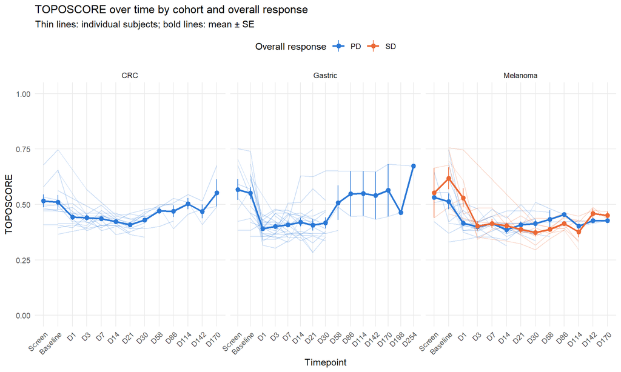

## 4.2 Summary table

TOPOSCORE by cohort and timepoint

| Cohort | Visit.Name.Norm | n | mean | sd | median | q1 | q3 |
| --- | --- | --- | --- | --- | --- | --- | --- |
| CRC | Screen | 8 | 0.516 | 0.083 | 0.488 | 0.476 | 0.545 |
| CRC | Baseline | 13 | 0.510 | 0.115 | 0.477 | 0.414 | 0.562 |
| CRC | D1 | 9 | 0.443 | 0.037 | 0.434 | 0.414 | 0.461 |
| CRC | D3 | 12 | 0.440 | 0.047 | 0.441 | 0.415 | 0.453 |
| CRC | D7 | 11 | 0.436 | 0.036 | 0.447 | 0.407 | 0.455 |
| CRC | D14 | 14 | 0.423 | 0.025 | 0.428 | 0.408 | 0.437 |
| CRC | D21 | 12 | 0.409 | 0.031 | 0.406 | 0.389 | 0.424 |
| CRC | D30 | 12 | 0.430 | 0.036 | 0.437 | 0.413 | 0.453 |
| CRC | D58 | 6 | 0.471 | 0.036 | 0.486 | 0.471 | 0.489 |
| CRC | D86 | 5 | 0.470 | 0.059 | 0.499 | 0.425 | 0.507 |
| CRC | D114 | 3 | 0.503 | 0.045 | 0.510 | 0.483 | 0.527 |
| CRC | D142 | 3 | 0.469 | 0.054 | 0.480 | 0.445 | 0.498 |
| CRC | D170 | 3 | 0.552 | 0.107 | 0.491 | 0.491 | 0.583 |
| Gastric | Screen | 8 | 0.567 | 0.135 | 0.561 | 0.464 | 0.683 |
| Gastric | Baseline | 16 | 0.551 | 0.113 | 0.572 | 0.456 | 0.630 |
| Gastric | D1 | 17 | 0.390 | 0.039 | 0.395 | 0.368 | 0.416 |
| Gastric | D3 | 17 | 0.401 | 0.052 | 0.401 | 0.366 | 0.447 |
| Gastric | D7 | 19 | 0.408 | 0.051 | 0.408 | 0.367 | 0.455 |
| Gastric | D14 | 15 | 0.420 | 0.076 | 0.406 | 0.366 | 0.446 |
| Gastric | D21 | 15 | 0.407 | 0.099 | 0.412 | 0.343 | 0.441 |
| Gastric | D30 | 13 | 0.417 | 0.090 | 0.379 | 0.357 | 0.469 |
| Gastric | D58 | 3 | 0.508 | 0.135 | 0.488 | 0.436 | 0.570 |
| Gastric | D86 | 2 | 0.548 | 0.144 | 0.548 | 0.497 | 0.599 |
| Gastric | D114 | 2 | 0.549 | 0.142 | 0.549 | 0.499 | 0.599 |
| Gastric | D142 | 2 | 0.540 | 0.151 | 0.540 | 0.487 | 0.594 |
| Gastric | D170 | 2 | 0.564 | 0.167 | 0.564 | 0.505 | 0.623 |
| Gastric | D198 | 1 | 0.464 | NA | 0.464 | 0.464 | 0.464 |
| Gastric | D254 | 1 | 0.673 | NA | 0.673 | 0.673 | 0.673 |
| Melanoma | Screen | 6 | 0.539 | 0.102 | 0.531 | 0.457 | 0.622 |
| Melanoma | Baseline | 19 | 0.552 | 0.133 | 0.521 | 0.471 | 0.681 |
| Melanoma | D1 | 19 | 0.457 | 0.094 | 0.434 | 0.405 | 0.487 |
| Melanoma | D3 | 18 | 0.401 | 0.040 | 0.395 | 0.380 | 0.421 |
| Melanoma | D7 | 17 | 0.414 | 0.041 | 0.414 | 0.395 | 0.447 |
| Melanoma | D14 | 17 | 0.393 | 0.042 | 0.406 | 0.368 | 0.414 |
| Melanoma | D21 | 16 | 0.401 | 0.043 | 0.391 | 0.379 | 0.415 |
| Melanoma | D30 | 17 | 0.395 | 0.055 | 0.395 | 0.366 | 0.431 |
| Melanoma | D58 | 11 | 0.400 | 0.043 | 0.392 | 0.370 | 0.416 |
| Melanoma | D86 | 9 | 0.418 | 0.032 | 0.410 | 0.390 | 0.446 |
| Melanoma | D114 | 7 | 0.380 | 0.059 | 0.403 | 0.333 | 0.426 |
| Melanoma | D142 | 4 | 0.451 | 0.035 | 0.450 | 0.424 | 0.477 |
| Melanoma | D170 | 3 | 0.443 | 0.023 | 0.432 | 0.430 | 0.451 |

# 5 LME model of TOPOSCORE over time

To test whether TOPOSCORE changes from Baseline, a linear mixed effects model is fit separately for each cohort:

`TOPOSCORE ~ Visit.Name.Norm + (1 | Subject_ID)`

- `Visit.Name.Norm` is a categorical fixed effect, with Baseline as the reference level.
- A random intercept for each subject accounts for repeated samples from the same subject. Random slopes are not used, because each cohort has too few subjects to estimate them reliably.
- Timepoints with fewer than 3 subjects in a cohort are dropped before fitting, because their estimates would be unstable.
- Each timepoint is compared with Baseline using estimated marginal means (emmeans). Degrees of freedom use the Satterthwaite method.
- P-values and confidence intervals are adjusted for multiple comparisons against a single reference, using emmeans’ default for this comparison (`adjust = "dunnettx"`). This is a fast, close approximation of Dunnett’s adjustment. The adjustment controls the familywise error rate within each cohort. It does not correct across cohorts.
- Subjects without a Baseline sample still contribute to the model through their other timepoints.

**Model interpretation:** a significant timepoint effect means that TOPOSCORE differs from Baseline at one or more timepoints. The per-timepoint contrasts show where the differences are. A singular fit means the subject-level variance was estimated as zero, so the model is effectively an ordinary linear model.

**1. Statistical Outcome** (`TOPOSCORE ~ Visit.Name.Norm + (1 | Subject_ID)`, Dunnett-adjusted)

- TOPOSCORE changes significantly over timepoints in all three cohorts (timepoint F-test p < 0.001 in CRC, Gastric, and Melanoma).
- Screen and Baseline do not differ in any cohort (estimates −0.010 to +0.007, all p > 0.99). Pre-treatment TOPOSCOREs are stable, so the later changes are unlikely to reflect pre-treatment drift.
- In every cohort, TOPOSCORE **decreases** after treatment starts. A lower TOPOSCORE means a less favorable SIG1/SIG2 balance.
- **Melanoma** (20 subjects): the decrease is significant at every timepoint from D1 through D170 (about −0.09 to −0.18; p ≤ 0.01). It has not returned to Baseline by the last modeled timepoint.
- **Gastric** (20 subjects): significant decreases from D1 through D30 (about −0.13 to −0.17; p < 0.001). D58 is not significantly different (−0.086, p = 0.19).
- **CRC** (14 subjects): smaller decreases, significant from D3 through D30 (about −0.07 to −0.11; p ≤ 0.02). D1 is borderline (−0.066, p = 0.06). From D58 onward, TOPOSCORE is no longer significantly different from Baseline (all p > 0.4), which suggests partial recovery.
- All CRC and Gastric subjects in this analysis are PD. Overall response could only be examined in Melanoma.

## 5.1 Overall timepoint effect

Type III F-test of `Visit.Name.Norm` within each cohort. A significant result means S scores differ across timepoints overall. The per-timepoint contrasts show where the differences are. A singular fit means the subject-level variance was estimated as zero, so the model is effectively an ordinary linear model.

Overall effect of timepoint on S score, by cohort

| Cohort | n_subjects | n_samples | singular | num_df | den_df | F_value | p_value |
| --- | --- | --- | --- | --- | --- | --- | --- |
| CRC | 14 | 111 | FALSE | 12 | 87.53 | 4.63 | 9e-06 |
| Melanoma | 20 | 163 | FALSE | 12 | 133.70 | 10.32 | 0e+00 |
| Gastric | 20 | 123 | FALSE | 8 | 98.44 | 14.52 | 0e+00 |

## 5.2 Contrasts vs Baseline

Each estimate is the model-estimated TOPOSCORE at that timepoint minus Baseline, with a 95% confidence interval and p-value, both Dunnett-adjusted.

TOPOSCORE change from Baseline by timepoint (LME, Dunnett-adjusted)

| Cohort | contrast | estimate | SE | df | lower.CL | upper.CL | p.value |
| --- | --- | --- | --- | --- | --- | --- | --- |
| CRC | Screen - Baseline | 0.000 | 0.025 | 88.2 | -0.070 | 0.070 | 1.00e+00 |
| CRC | D1 - Baseline | -0.066 | 0.024 | 88.0 | -0.133 | 0.002 | 6.18e-02 |
| CRC | D3 - Baseline | -0.072 | 0.022 | 86.5 | -0.134 | -0.010 | 1.39e-02 |
| CRC | D7 - Baseline | -0.072 | 0.022 | 86.6 | -0.135 | -0.008 | 1.82e-02 |
| CRC | D14 - Baseline | -0.088 | 0.021 | 84.9 | -0.147 | -0.028 | 6.90e-04 |
| CRC | D21 - Baseline | -0.105 | 0.022 | 86.0 | -0.167 | -0.043 | 6.70e-05 |
| CRC | D30 - Baseline | -0.082 | 0.022 | 86.3 | -0.144 | -0.020 | 3.14e-03 |
| CRC | D58 - Baseline | -0.048 | 0.027 | 89.6 | -0.125 | 0.030 | 4.64e-01 |
| CRC | D86 - Baseline | -0.041 | 0.029 | 90.0 | -0.124 | 0.042 | 6.94e-01 |
| CRC | D114 - Baseline | -0.003 | 0.035 | 89.9 | -0.104 | 0.099 | 1.00e+00 |
| CRC | D142 - Baseline | -0.037 | 0.035 | 89.9 | -0.138 | 0.064 | 8.72e-01 |
| CRC | D170 - Baseline | 0.046 | 0.035 | 89.9 | -0.055 | 0.147 | 7.47e-01 |
| Gastric | Screen - Baseline | 0.007 | 0.027 | 99.4 | -0.067 | 0.081 | 9.98e-01 |
| Gastric | D1 - Baseline | -0.166 | 0.021 | 98.1 | -0.224 | -0.108 | 0.00e+00 |
| Gastric | D3 - Baseline | -0.153 | 0.021 | 98.2 | -0.212 | -0.095 | 0.00e+00 |
| Gastric | D7 - Baseline | -0.146 | 0.021 | 97.6 | -0.203 | -0.090 | 0.00e+00 |
| Gastric | D14 - Baseline | -0.136 | 0.022 | 97.5 | -0.196 | -0.076 | 1.00e-07 |
| Gastric | D21 - Baseline | -0.145 | 0.022 | 98.0 | -0.205 | -0.085 | 0.00e+00 |
| Gastric | D30 - Baseline | -0.131 | 0.023 | 97.9 | -0.194 | -0.069 | 1.00e-06 |
| Gastric | D58 - Baseline | -0.086 | 0.040 | 100.2 | -0.195 | 0.023 | 1.89e-01 |
| Melanoma | Screen - Baseline | -0.010 | 0.029 | 135.0 | -0.093 | 0.073 | 9.99e-01 |
| Melanoma | D1 - Baseline | -0.095 | 0.020 | 130.0 | -0.151 | -0.038 | 5.98e-05 |
| Melanoma | D3 - Baseline | -0.148 | 0.020 | 130.4 | -0.205 | -0.091 | 0.00e+00 |
| Melanoma | D7 - Baseline | -0.138 | 0.021 | 130.8 | -0.196 | -0.079 | 0.00e+00 |
| Melanoma | D14 - Baseline | -0.154 | 0.021 | 132.0 | -0.212 | -0.096 | 0.00e+00 |
| Melanoma | D21 - Baseline | -0.148 | 0.021 | 131.4 | -0.208 | -0.089 | 0.00e+00 |
| Melanoma | D30 - Baseline | -0.160 | 0.021 | 132.1 | -0.219 | -0.102 | 0.00e+00 |
| Melanoma | D58 - Baseline | -0.156 | 0.024 | 135.0 | -0.223 | -0.089 | 0.00e+00 |
| Melanoma | D86 - Baseline | -0.142 | 0.025 | 136.0 | -0.214 | -0.070 | 1.50e-06 |
| Melanoma | D114 - Baseline | -0.176 | 0.028 | 134.3 | -0.254 | -0.097 | 0.00e+00 |
| Melanoma | D142 - Baseline | -0.138 | 0.035 | 137.4 | -0.236 | -0.039 | 1.37e-03 |
| Melanoma | D170 - Baseline | -0.133 | 0.039 | 134.8 | -0.244 | -0.022 | 9.44e-03 |

## 5.3 LME contrast plot - all cohorts

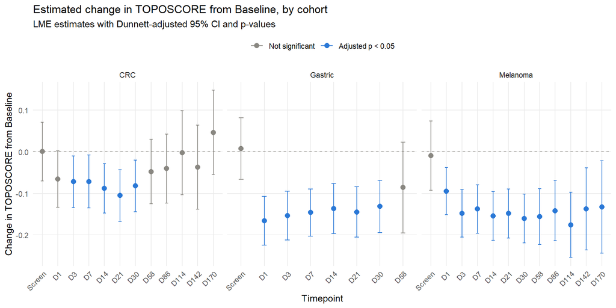

# 6 LME model of Melanoma TOPOSCORE with overall response

For the Melanoma cohort only, a timepoint × overall response interaction model is fit:

`TOPOSCORE ~ Visit.Name.Norm * Overall_Response + (1 | Subject_ID)`

- The interaction lets each response group have its own TOPOSCORE trajectory over timepoints, rather than assuming parallel trajectories.
- Subjects with a missing `Overall_Response` are excluded.
- A timepoint is kept only if every response group has at least 3 subjects at that timepoint. An interaction model needs data in every timepoint × response cell, and cells with very few subjects give unstable estimates. The first tab shows the subjects in each cell after filtering.
- The most common response group is the reference level.
- Three sets of comparisons are reported:
  - **Change from Baseline within each response group:** each timepoint vs Baseline, Dunnett-adjusted within each group.
  - **Response difference at each timepoint:** the difference between response groups at each timepoint. No adjustment is applied.
  - **Difference in change from Baseline:** whether the change from Baseline at each timepoint differs between response groups. This is the interaction contrast. It is Dunnett-adjusted across timepoints.

**Interpretation caution:** group sizes are still small. Check the subject counts in the first tab before interpreting group-specific estimates. Treat estimates from cells with only a few subjects as descriptive.

**Model interpretation:** a significant timepoint × response interaction means that the TOPOSCORE trajectories differ between response groups. A significant main effect of response means that the average TOPOSCORE differs between response groups, averaged over timepoints. A significant main effect of timepoint means that the average TOPOSCORE differs between timepoints, averaged over response groups. The main effects are not interpreted if the interaction is significant.

**2. Statistical Outcome** (`TOPOSCORE ~ Visit.Name.Norm * Overall_Response + (1 | Subject_ID)`; 12 PD and 8 SD subjects, Baseline through D58)

- The timepoint × response interaction is significant (F = 3.87, p < 0.001). PD and SD subjects follow different TOPOSCORE trajectories.
- The overall response main effect is not significant (F = 1.06, p = 0.32). Averaged over timepoints, SD and PD do not differ. Because the interaction is significant, this average hides a timepoint-dependent difference.
- **Higher starting TOPOSCORE in SD:** at Baseline and D1, SD subjects have higher TOPOSCOREs than PD subjects (+0.10, p = 0.002; +0.11, p < 0.001). From D3 onward, the two groups no longer differ (all p > 0.2).
- **Both groups decrease from Baseline:**
  - PD decreases by about −0.10 to −0.13 from D1 through D30 (all p < 0.001). D58 is not significant (−0.074, p = 0.28), but only 3 PD subjects contribute.
  - SD decreases at every timepoint, from −0.088 at D1 (p = 0.03) to about −0.20 to −0.24 from D3 through D58 (all p < 0.001).
- **Larger decrease in SD:** the SD decrease is significantly larger than the PD decrease at D21 (−0.12, p = 0.04), D30 (−0.14, p = 0.006), and D58 (−0.15, p = 0.01). The difference is not significant from D1 through D14.
- Taken together, SD subjects start with a higher TOPOSCORE, but lose that advantage after treatment starts. By D3 they are at a similar level to PD.

## 6.1 Subjects by response and timepoint

Melanoma subjects per overall response and timepoint (timepoints used in the model)

| Overall_Response | Baseline | D1 | D3 | D7 | D14 | D21 | D30 | D58 | Total subjects |
| --- | --- | --- | --- | --- | --- | --- | --- | --- | --- |
| PD | 12 | 12 | 12 | 11 | 10 | 10 | 9 | 3 | 12 |
| SD | 7 | 7 | 6 | 6 | 7 | 6 | 8 | 8 | 8 |

## 6.2 Model tests

Type III F-tests for timepoint, overall response, and their interaction. A significant interaction means the TOPOSCORE trajectory over timepoints differs between response groups. A singular fit means the subject-level variance was estimated as zero.

Melanoma: timepoint × overall response effects on TOPOSCORE

| term | num_df | den_df | F_value | p_value | singular_fit |
| --- | --- | --- | --- | --- | --- |
| Visit.Name.Norm | 7 | 100.45 | 16.84 | 0.000000 | FALSE |
| Overall_Response | 1 | 16.92 | 1.06 | 0.318000 | FALSE |
| Visit.Name.Norm:Overall_Response | 7 | 100.45 | 3.87 | 0.000899 | FALSE |

## 6.3 Change from Baseline by response

Change in estimated TOPOSCORE from Baseline at each timepoint, within each response group. P-values and CIs are Dunnett-adjusted within each group.

Melanoma: TOPOSCORE change from Baseline by response (Dunnett-adjusted)

| Overall_Response | contrast | estimate | SE | df | lower.CL | upper.CL | p.value |
| --- | --- | --- | --- | --- | --- | --- | --- |
| PD | D1 - Baseline | -0.098 | 0.024 | 98.4 | -0.162 | -0.034 | 5.67e-04 |
| PD | D3 - Baseline | -0.114 | 0.024 | 98.4 | -0.178 | -0.050 | 4.49e-05 |
| PD | D7 - Baseline | -0.104 | 0.025 | 98.9 | -0.170 | -0.038 | 3.38e-04 |
| PD | D14 - Baseline | -0.126 | 0.025 | 99.7 | -0.193 | -0.058 | 1.87e-05 |
| PD | D21 - Baseline | -0.104 | 0.025 | 99.9 | -0.172 | -0.036 | 5.27e-04 |
| PD | D30 - Baseline | -0.104 | 0.026 | 100.4 | -0.174 | -0.035 | 8.08e-04 |
| PD | D58 - Baseline | -0.074 | 0.039 | 104.5 | -0.178 | 0.031 | 2.81e-01 |
| SD | D1 - Baseline | -0.088 | 0.031 | 98.4 | -0.172 | -0.004 | 3.46e-02 |
| SD | D3 - Baseline | -0.205 | 0.033 | 99.8 | -0.293 | -0.117 | 1.00e-07 |
| SD | D7 - Baseline | -0.194 | 0.033 | 99.8 | -0.282 | -0.106 | 3.00e-07 |
| SD | D14 - Baseline | -0.204 | 0.032 | 101.7 | -0.288 | -0.119 | 0.00e+00 |
| SD | D21 - Baseline | -0.220 | 0.033 | 99.8 | -0.308 | -0.132 | 0.00e+00 |
| SD | D30 - Baseline | -0.242 | 0.031 | 100.1 | -0.324 | -0.160 | 0.00e+00 |
| SD | D58 - Baseline | -0.228 | 0.031 | 100.1 | -0.310 | -0.147 | 0.00e+00 |

## 6.4 Response difference by timepoint

Difference in estimated TOPOSCORE between response groups at each timepoint. No multiple-comparison adjustment is applied.

Melanoma: TOPOSCORE difference between response groups by timepoint

| Visit.Name.Norm | contrast | estimate | SE | df | lower.CL | upper.CL | p.value |
| --- | --- | --- | --- | --- | --- | --- | --- |
| Baseline | SD - PD | 0.102 | 0.032 | 87.2 | 0.038 | 0.166 | 0.002100 |
| D1 | SD - PD | 0.112 | 0.032 | 87.2 | 0.048 | 0.176 | 0.000787 |
| D3 | SD - PD | 0.011 | 0.034 | 92.5 | -0.056 | 0.077 | 0.749000 |
| D7 | SD - PD | 0.012 | 0.034 | 94.1 | -0.055 | 0.080 | 0.723000 |
| D14 | SD - PD | 0.024 | 0.033 | 91.4 | -0.042 | 0.090 | 0.468000 |
| D21 | SD - PD | -0.014 | 0.035 | 95.7 | -0.083 | 0.054 | 0.684000 |
| D30 | SD - PD | -0.036 | 0.033 | 90.1 | -0.101 | 0.029 | 0.280000 |
| D58 | SD - PD | -0.053 | 0.044 | 114.6 | -0.140 | 0.034 | 0.230000 |

## 6.5 Difference in change from Baseline

Whether the change from Baseline at each timepoint differs between response groups. For example, “D7 - Baseline, SD - PD” is SD’s change from Baseline to D7 minus PD’s change over the same interval. P-values and CIs are Dunnett-adjusted across timepoints.

Melanoma: difference between response groups in change from Baseline

| contrast | estimate | SE | df | lower.CL | upper.CL | p.value |
| --- | --- | --- | --- | --- | --- | --- |
| D1 - Baseline, SD - PD | 0.010 | 0.039 | 98.4 | -0.096 | 0.116 | 0.99700 |
| D3 - Baseline, SD - PD | -0.091 | 0.041 | 99.3 | -0.200 | 0.018 | 0.13900 |
| D7 - Baseline, SD - PD | -0.090 | 0.041 | 99.5 | -0.200 | 0.020 | 0.15500 |
| D14 - Baseline, SD - PD | -0.078 | 0.041 | 100.9 | -0.186 | 0.031 | 0.26400 |
| D21 - Baseline, SD - PD | -0.116 | 0.041 | 99.8 | -0.227 | -0.005 | 0.03600 |
| D30 - Baseline, SD - PD | -0.138 | 0.040 | 100.2 | -0.245 | -0.030 | 0.00574 |
| D58 - Baseline, SD - PD | -0.155 | 0.050 | 102.9 | -0.288 | -0.022 | 0.01450 |

## 6.6 LME contrast plot - Melanoma

Lines are model-estimated means with 95% CIs from the interaction model, so each response group has its own trajectory. Points are the observed TOPOSCOREs.

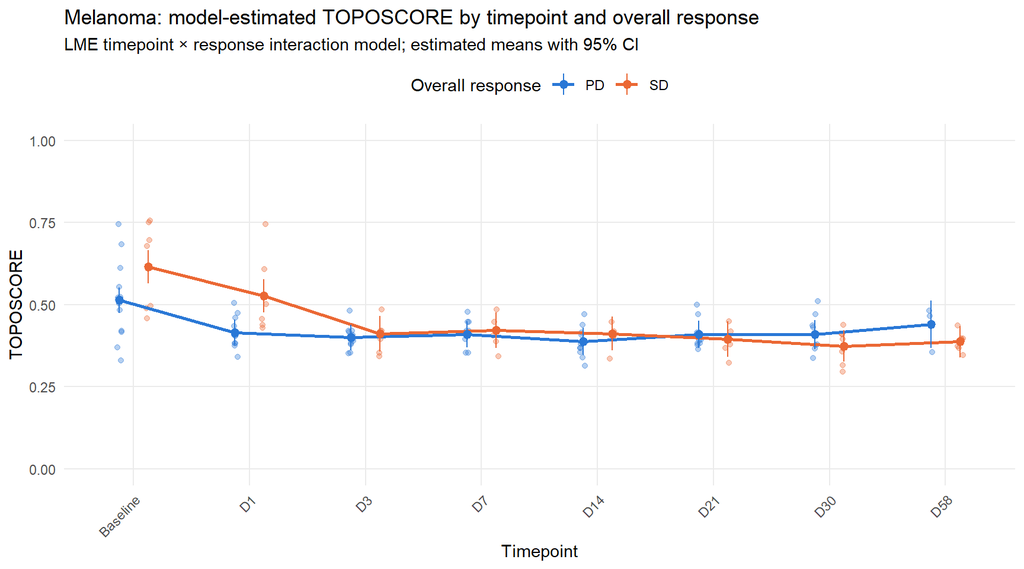

# 7 Export

Per-sample TOPOSCORES and summary and model tables are written to the `output/` folder. Figures are saved to the same folder when each plot is drawn.